# Computer Science 1

**Computer lab 05**

**Course Number:** BTPS1210BA-E  
**Contact Information:** Please contact me through email anytime: abari.kalman@arts.unideb.hu

Author

Kálmán Abari

Published

August 28, 2024

Learning outcomes

Students will learn how to navigate in jamovi.

# Jamovi - Introduction

## Problem 1

> In this section, you will learn how to check your jamovi version.

Let’s try to answer the question, which jamovi version am I running, is there a newer one?

1. Open the *jamovi* statistical software (If it is not installed on your computer, you can do this from https://jamovi.org).

[figure not shown]

Screenshot of *jamovi* immediately after launch

2. Check the version number of *jamovi* running on your computer. There are two methods. The current version number is available from the home screen.

[figure not shown]

Version of *jamovi* on home screen

Also, by clicking on the 3 dots in the upper right corner, you can also see the version number at the bottom of the window that appears.

[figure not shown]

3 dots to setup jamovi

[figure not shown]

Version of *jamovi* on setup window

3. Compare the version number of *jamovi* running on your computer to the latest version available from https://jamovi.org.

[figure not shown]

The latest version available from https://jamovi.org

As you can see, we are using the latest version of *jamovi*. We have nothing to do, *jamovi* is up-to-date. We check the *jamovi* site every two to three months to see if a new version of *jamovi* is available.

## Problem 2

> In this section, you will learn how to navigate in jamovi.

The user interface of *jamovi* is structured extremely logically. It is important to be aware of how we can access the 3 panels:

- **Data panel:** In a *jamovi* program instance, we can always analyse only one dataset. This dataset is what ‘Data panel’ contains.
- **Analysis panel:** We can initiate any number of analyses from the menu `Analayses`. We always see the current analysis in the ‘Analysis panel’.
- **Results panel:** Each analysis has a separate results section. The results of all analyses performed in the jamov instance are available in the ‘Results panel’. By clicking on a result section, the corresponding analysis section will be loaded into the ‘Analysis panel’.
1. Open the *jamovi* statistical software.
2. Identify the panels that appear. After starting, only the ‘Data panel’ is visible.

[figure not shown]

Data panel

3. Select the menu `Exploration / Descriptive` and identify the panels that appear. Two bars are separating the three panels, and these can be dragged to the left or the right to change their sizes.

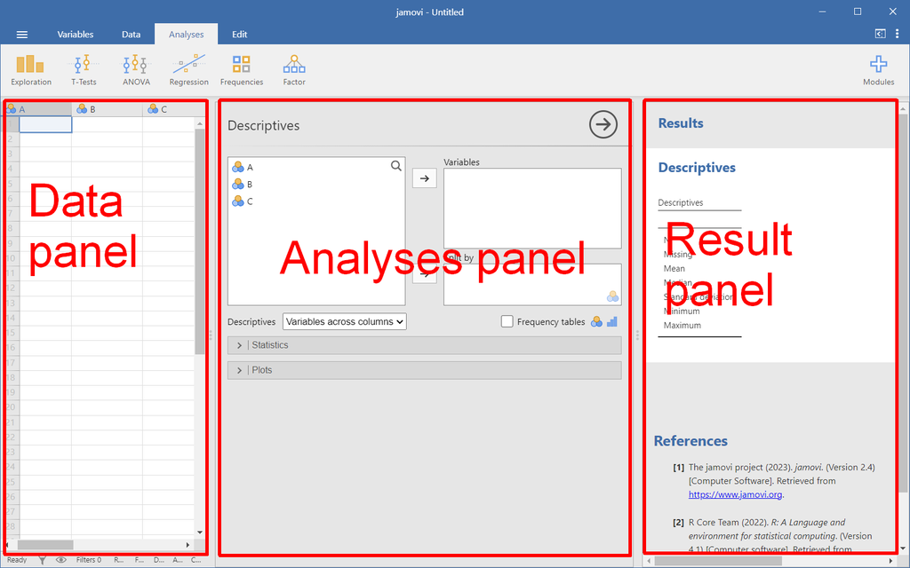

Data panel, Analyses panel, and Result panel

4. Hide the ‘Analyses panel’. Click on the arrow in the upper right corner of the ‘Analyses panel’.

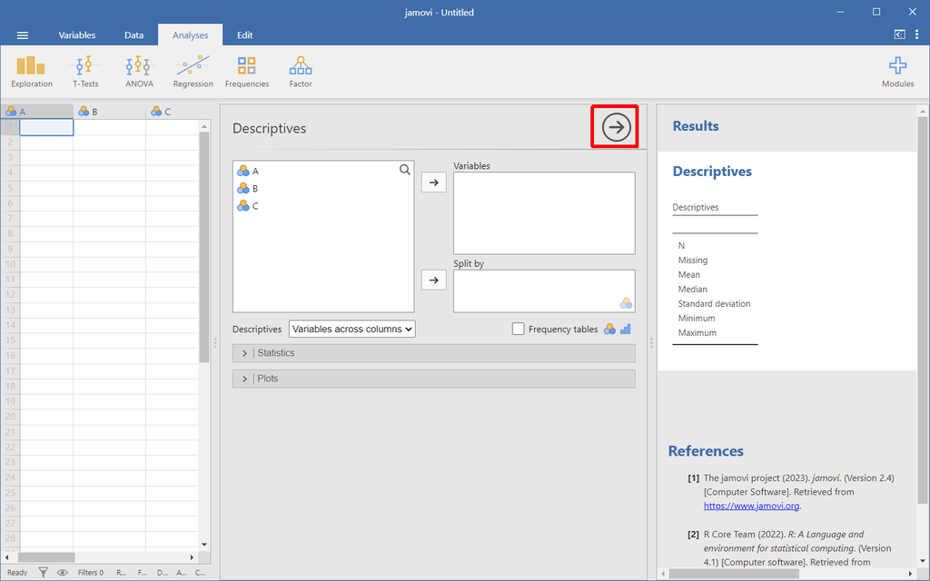

Hiding Analyses panel

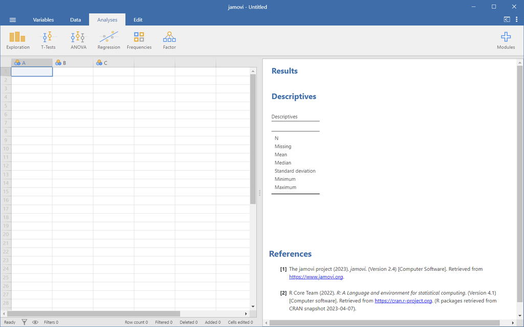

After hiding and resizing

5. Show the ‘Analyses panel’. Click on Descriptive part of the ‘Result pane’.

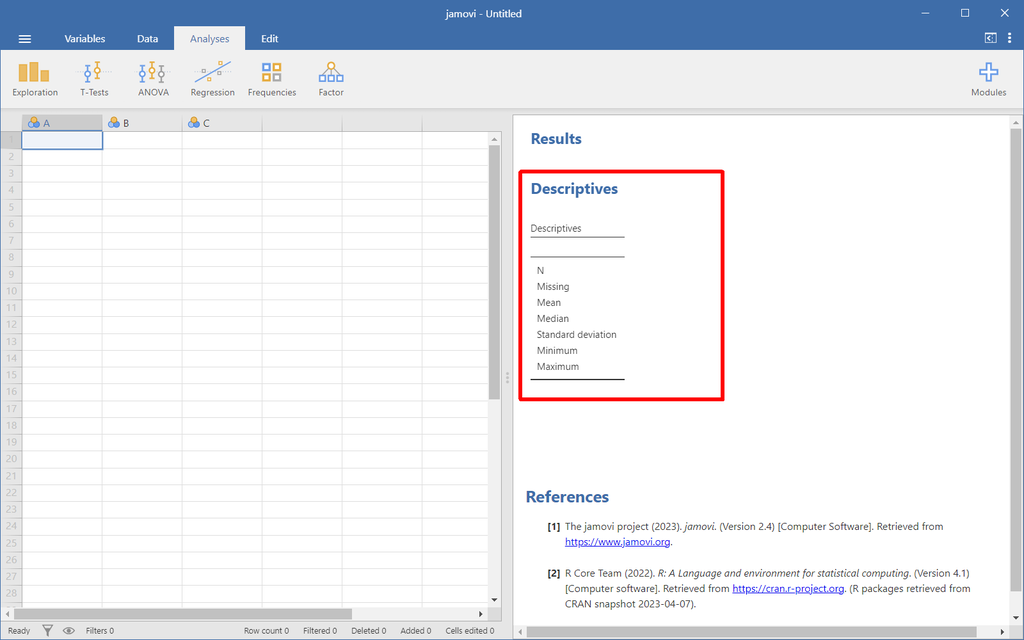

Showing Analyses panel

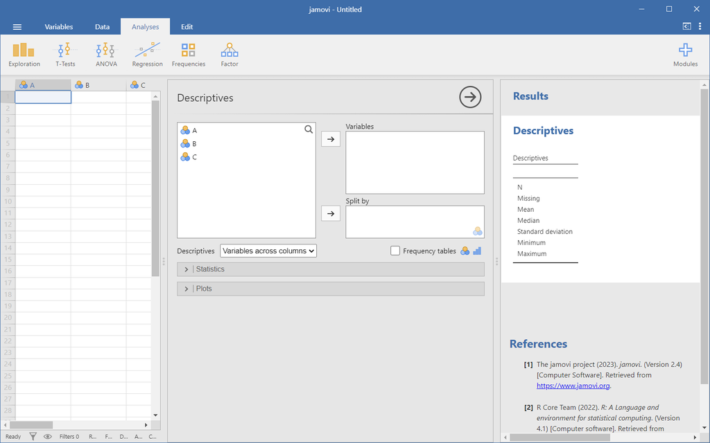

After showing and resizing

6. Hide the ‘Data panel’. Click on the small icon in the upper right corner of the *jamovi*.

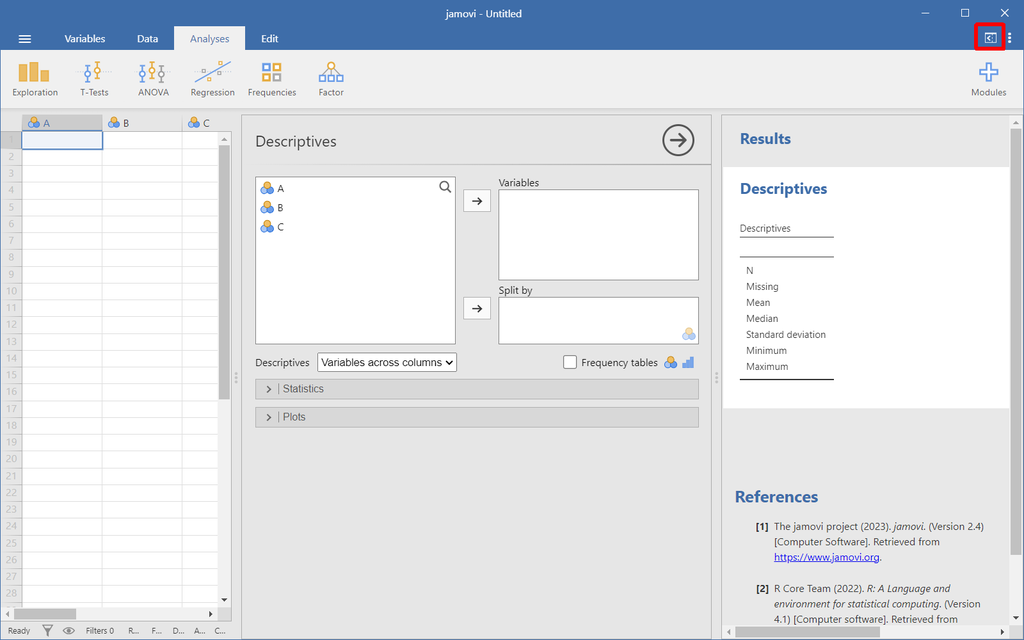

Hiding Data panel

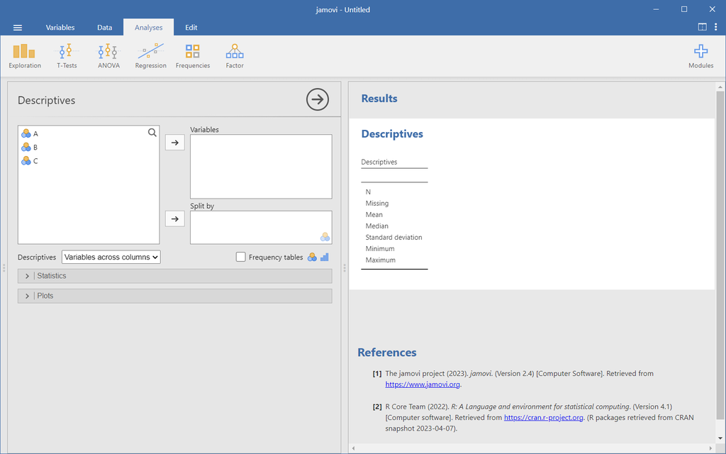

After hiding

7. Show the ‘Data panel’. Click on the small icon in the upper right corner of the *jamovi*.

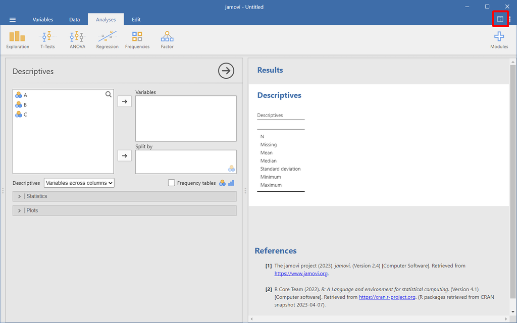

Showing Data panel

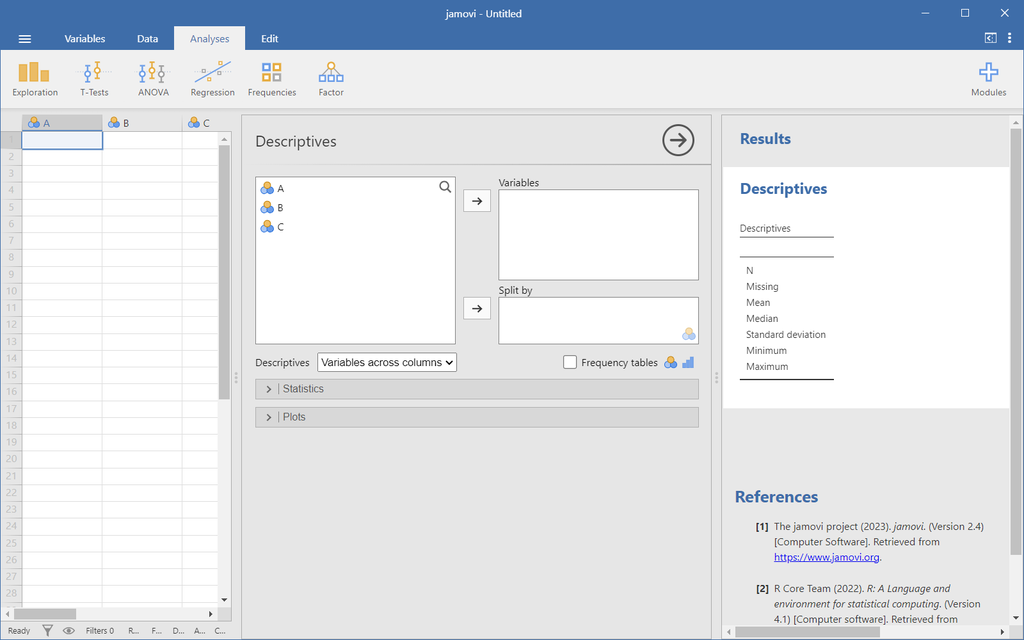

After showing

8. Create another analysis using `Analyses / T-Test / One Sample T-test`. Note that a new analysis section has been added to the ‘Result panel’. The ‘Result panel’ now contains two analysis sections.

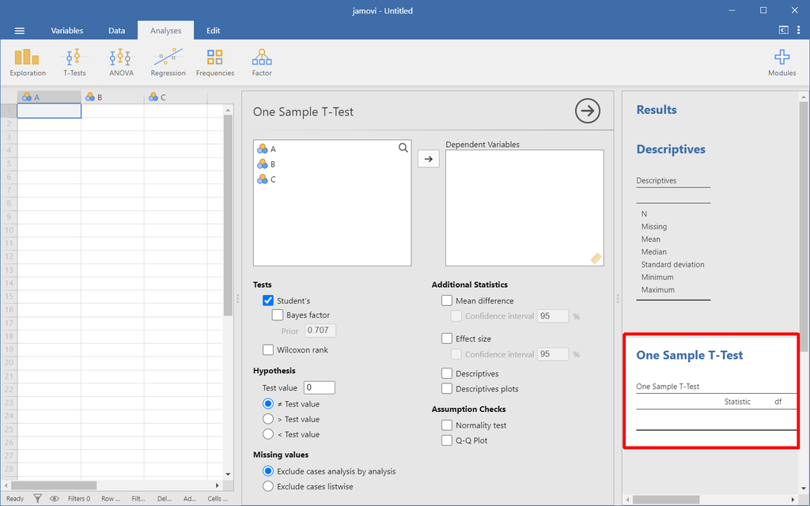

A new analaysis section

9. Let’s make available the ‘Analyzes panel’ belonging to the first analysis section (Descriptive statistics). Click on Descriptive part of ‘Result panel’

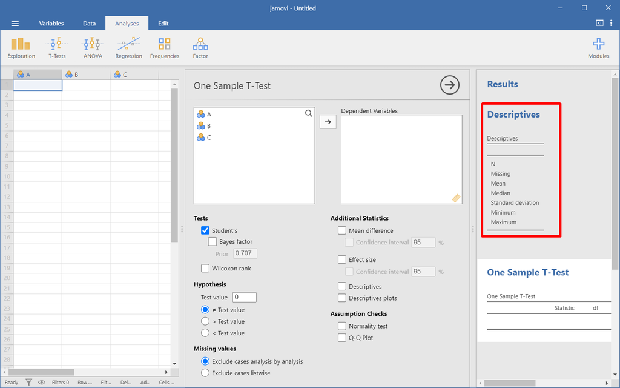

Switch to Descriptive analyses

[figure not shown]

After switching